# Risk Factor Analysis

## Outcome Variable

**Outcome Variable:** wasted

## Predictor Variables

**Intervention Variable:** mage

**Adjustment Set:**

- arm
- meducyrs
- feducyrs
- W_mhtcm
- W_mwtkg
- W_mbmi
- single
- delta_meducyrs
- delta_feducyrs
- delta_W_mhtcm
- delta_W_mwtkg
- delta_W_mbmi
- delta_single

## Stratifying Variables

The analysis was stratified on these variable(s):

- agecat
- studyid
- country

## Data Summary

| agecat | studyid | country | mage | wasted | n_cell | n |
| --- | --- | --- | --- | --- | --- | --- |
| Birth | CMC-V-BCS-2002 | INDIA | [20-30) | 0 | 66 | 86 |
| Birth | CMC-V-BCS-2002 | INDIA | [20-30) | 1 | 9 | 86 |
| Birth | CMC-V-BCS-2002 | INDIA | <20 | 0 | 5 | 86 |
| Birth | CMC-V-BCS-2002 | INDIA | <20 | 1 | 2 | 86 |
| Birth | CMC-V-BCS-2002 | INDIA | >=30 | 0 | 4 | 86 |
| Birth | CMC-V-BCS-2002 | INDIA | >=30 | 1 | 0 | 86 |
| Birth | COHORTS | GUATEMALA | [20-30) | 0 | 277 | 756 |
| Birth | COHORTS | GUATEMALA | [20-30) | 1 | 90 | 756 |
| Birth | COHORTS | GUATEMALA | <20 | 0 | 68 | 756 |
| Birth | COHORTS | GUATEMALA | <20 | 1 | 33 | 756 |
| Birth | COHORTS | GUATEMALA | >=30 | 0 | 219 | 756 |
| Birth | COHORTS | GUATEMALA | >=30 | 1 | 69 | 756 |
| Birth | COHORTS | INDIA | [20-30) | 0 | 2472 | 4405 |
| Birth | COHORTS | INDIA | [20-30) | 1 | 493 | 4405 |
| Birth | COHORTS | INDIA | <20 | 0 | 264 | 4405 |
| Birth | COHORTS | INDIA | <20 | 1 | 73 | 4405 |
| Birth | COHORTS | INDIA | >=30 | 0 | 905 | 4405 |
| Birth | COHORTS | INDIA | >=30 | 1 | 198 | 4405 |
| Birth | COHORTS | PHILIPPINES | [20-30) | 0 | 1466 | 2899 |
| Birth | COHORTS | PHILIPPINES | [20-30) | 1 | 278 | 2899 |
| Birth | COHORTS | PHILIPPINES | <20 | 0 | 281 | 2899 |
| Birth | COHORTS | PHILIPPINES | <20 | 1 | 73 | 2899 |
| Birth | COHORTS | PHILIPPINES | >=30 | 0 | 701 | 2899 |
| Birth | COHORTS | PHILIPPINES | >=30 | 1 | 100 | 2899 |
| Birth | EE | PAKISTAN | [20-30) | 0 | 62 | 177 |
| Birth | EE | PAKISTAN | [20-30) | 1 | 6 | 177 |
| Birth | EE | PAKISTAN | <20 | 0 | 0 | 177 |
| Birth | EE | PAKISTAN | <20 | 1 | 1 | 177 |
| Birth | EE | PAKISTAN | >=30 | 0 | 93 | 177 |
| Birth | EE | PAKISTAN | >=30 | 1 | 15 | 177 |

[output cut: 396 more lines]

The following strata were considered:

- agecat: 24 months, studyid: CMC-V-BCS-2002, country: INDIA
- agecat: 24 months, studyid: COHORTS, country: GUATEMALA
- agecat: 24 months, studyid: COHORTS, country: INDIA
- agecat: 24 months, studyid: COHORTS, country: PHILIPPINES
- agecat: 24 months, studyid: EE, country: PAKISTAN
- agecat: 24 months, studyid: GMS-Nepal, country: NEPAL
- agecat: 24 months, studyid: IRC, country: INDIA
- agecat: 24 months, studyid: JiVitA-3, country: BANGLADESH
- agecat: 24 months, studyid: Keneba, country: GAMBIA
- agecat: 24 months, studyid: LCNI-5, country: MALAWI
- agecat: 24 months, studyid: MAL-ED, country: BANGLADESH
- agecat: 24 months, studyid: MAL-ED, country: BRAZIL
- agecat: 24 months, studyid: MAL-ED, country: INDIA
- agecat: 24 months, studyid: MAL-ED, country: NEPAL
- agecat: 24 months, studyid: MAL-ED, country: PERU
- agecat: 24 months, studyid: MAL-ED, country: SOUTH AFRICA
- agecat: 24 months, studyid: MAL-ED, country: TANZANIA, UNITED REPUBLIC OF
- agecat: 24 months, studyid: NIH-Birth, country: BANGLADESH
- agecat: 24 months, studyid: NIH-Crypto, country: BANGLADESH
- agecat: 24 months, studyid: PROBIT, country: BELARUS
- agecat: 24 months, studyid: PROVIDE, country: BANGLADESH
- agecat: 24 months, studyid: TanzaniaChild2, country: TANZANIA, UNITED REPUBLIC OF
- agecat: 24 months, studyid: ZVITAMBO, country: ZIMBABWE
- agecat: 6 months, studyid: CMC-V-BCS-2002, country: INDIA
- agecat: 6 months, studyid: COHORTS, country: GUATEMALA
- agecat: 6 months, studyid: COHORTS, country: INDIA
- agecat: 6 months, studyid: COHORTS, country: PHILIPPINES
- agecat: 6 months, studyid: EE, country: PAKISTAN
- agecat: 6 months, studyid: GMS-Nepal, country: NEPAL
- agecat: 6 months, studyid: Guatemala BSC, country: GUATEMALA
- agecat: 6 months, studyid: IRC, country: INDIA
- agecat: 6 months, studyid: JiVitA-3, country: BANGLADESH
- agecat: 6 months, studyid: Keneba, country: GAMBIA
- agecat: 6 months, studyid: LCNI-5, country: MALAWI
- agecat: 6 months, studyid: MAL-ED, country: BANGLADESH
- agecat: 6 months, studyid: MAL-ED, country: BRAZIL
- agecat: 6 months, studyid: MAL-ED, country: INDIA
- agecat: 6 months, studyid: MAL-ED, country: NEPAL
- agecat: 6 months, studyid: MAL-ED, country: PERU
- agecat: 6 months, studyid: MAL-ED, country: SOUTH AFRICA
- agecat: 6 months, studyid: MAL-ED, country: TANZANIA, UNITED REPUBLIC OF
- agecat: 6 months, studyid: NIH-Birth, country: BANGLADESH
- agecat: 6 months, studyid: NIH-Crypto, country: BANGLADESH
- agecat: 6 months, studyid: PROBIT, country: BELARUS
- agecat: 6 months, studyid: PROVIDE, country: BANGLADESH
- agecat: 6 months, studyid: SAS-CompFeed, country: INDIA
- agecat: 6 months, studyid: SAS-FoodSuppl, country: INDIA
- agecat: 6 months, studyid: TanzaniaChild2, country: TANZANIA, UNITED REPUBLIC OF
- agecat: 6 months, studyid: ZVITAMBO, country: ZIMBABWE
- agecat: Birth, studyid: CMC-V-BCS-2002, country: INDIA
- agecat: Birth, studyid: COHORTS, country: GUATEMALA
- agecat: Birth, studyid: COHORTS, country: INDIA
- agecat: Birth, studyid: COHORTS, country: PHILIPPINES
- agecat: Birth, studyid: EE, country: PAKISTAN
- agecat: Birth, studyid: GMS-Nepal, country: NEPAL
- agecat: Birth, studyid: IRC, country: INDIA
- agecat: Birth, studyid: JiVitA-3, country: BANGLADESH
- agecat: Birth, studyid: Keneba, country: GAMBIA
- agecat: Birth, studyid: MAL-ED, country: BANGLADESH
- agecat: Birth, studyid: MAL-ED, country: BRAZIL
- agecat: Birth, studyid: MAL-ED, country: INDIA
- agecat: Birth, studyid: MAL-ED, country: NEPAL
- agecat: Birth, studyid: MAL-ED, country: PERU
- agecat: Birth, studyid: MAL-ED, country: SOUTH AFRICA
- agecat: Birth, studyid: MAL-ED, country: TANZANIA, UNITED REPUBLIC OF
- agecat: Birth, studyid: NIH-Birth, country: BANGLADESH
- agecat: Birth, studyid: NIH-Crypto, country: BANGLADESH
- agecat: Birth, studyid: PROBIT, country: BELARUS
- agecat: Birth, studyid: PROVIDE, country: BANGLADESH
- agecat: Birth, studyid: SAS-CompFeed, country: INDIA
- agecat: Birth, studyid: ZVITAMBO, country: ZIMBABWE

### Dropped Strata

Some strata were dropped due to rare outcomes:

- agecat: Birth, studyid: CMC-V-BCS-2002, country: INDIA
- agecat: Birth, studyid: EE, country: PAKISTAN
- agecat: Birth, studyid: MAL-ED, country: BRAZIL
- agecat: Birth, studyid: MAL-ED, country: INDIA
- agecat: Birth, studyid: MAL-ED, country: NEPAL
- agecat: Birth, studyid: MAL-ED, country: PERU
- agecat: Birth, studyid: MAL-ED, country: SOUTH AFRICA
- agecat: Birth, studyid: MAL-ED, country: TANZANIA, UNITED REPUBLIC OF
- agecat: 6 months, studyid: CMC-V-BCS-2002, country: INDIA
- agecat: 6 months, studyid: COHORTS, country: GUATEMALA
- agecat: 6 months, studyid: EE, country: PAKISTAN
- agecat: 6 months, studyid: Guatemala BSC, country: GUATEMALA
- agecat: 6 months, studyid: LCNI-5, country: MALAWI
- agecat: 6 months, studyid: MAL-ED, country: BANGLADESH
- agecat: 6 months, studyid: MAL-ED, country: BRAZIL
- agecat: 6 months, studyid: MAL-ED, country: INDIA
- agecat: 6 months, studyid: MAL-ED, country: NEPAL
- agecat: 6 months, studyid: MAL-ED, country: PERU
- agecat: 6 months, studyid: MAL-ED, country: SOUTH AFRICA
- agecat: 6 months, studyid: MAL-ED, country: TANZANIA, UNITED REPUBLIC OF
- agecat: 6 months, studyid: NIH-Birth, country: BANGLADESH
- agecat: 6 months, studyid: NIH-Crypto, country: BANGLADESH
- agecat: 6 months, studyid: PROVIDE, country: BANGLADESH
- agecat: 6 months, studyid: SAS-FoodSuppl, country: INDIA
- agecat: 24 months, studyid: CMC-V-BCS-2002, country: INDIA
- agecat: 24 months, studyid: EE, country: PAKISTAN
- agecat: 24 months, studyid: IRC, country: INDIA
- agecat: 24 months, studyid: LCNI-5, country: MALAWI
- agecat: 24 months, studyid: MAL-ED, country: BANGLADESH
- agecat: 24 months, studyid: MAL-ED, country: BRAZIL
- agecat: 24 months, studyid: MAL-ED, country: INDIA
- agecat: 24 months, studyid: MAL-ED, country: NEPAL
- agecat: 24 months, studyid: MAL-ED, country: PERU
- agecat: 24 months, studyid: MAL-ED, country: SOUTH AFRICA
- agecat: 24 months, studyid: MAL-ED, country: TANZANIA, UNITED REPUBLIC OF
- agecat: 24 months, studyid: NIH-Birth, country: BANGLADESH
- agecat: 24 months, studyid: PROBIT, country: BELARUS
- agecat: 24 months, studyid: TanzaniaChild2, country: TANZANIA, UNITED REPUBLIC OF

## Methods Detail

We’re interested in the causal parameters $E[Y_a]$ for all values of $a \in \mathcal{A}$. These parameters represent the mean outcome if, possibly contrary to fact, we intervened to set all units to have $A=a$. Under the randomization and positivity assumptions, these are identified by the statistical parameters $\psi_a=E_W[E_{Y|A,W}(Y|A=a,W)]$. In addition, we’re interested in the mean of $Y$, $E[Y]$ under no intervention (the observed mean). We will estimate these parameters by using SuperLearner to fit the relevant likelihood factors – $E_{Y|A,W}(Y|A=a,W)$ and $p(A=a|W)$, and then updating our likelihood fit using a joint TMLE.

For unadjusted analyses ($W=\{\}$), initial likelihoods were estimated using Lrnr_glm to estimate the simple $E(Y|A)$ and Lrnr_mean to estimate $p(A)$. For adjusted analyses, a small library containing Lrnr_glmnet, Lrnr_xgboost, and Lrnr_mean was used.

Having estimated these parameters, we will then use the delta method to estimate relative risks and attributable risks relative to a prespecified baseline level of $A$.

# Results Detail

## Results Plots

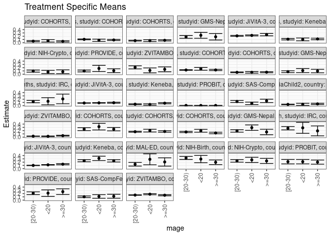

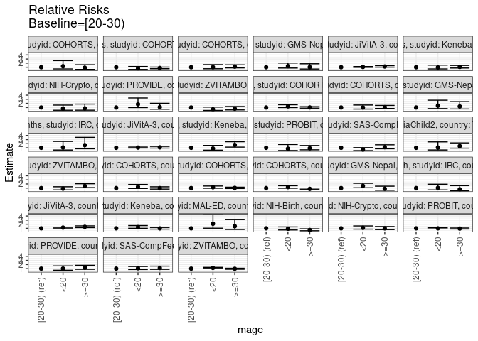

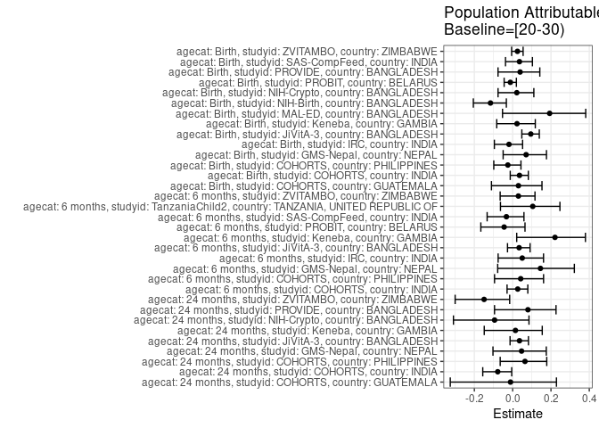

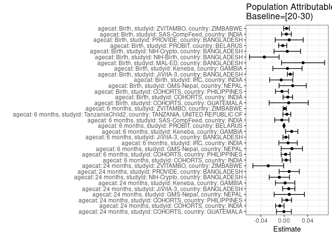

## Results Table

### Parameter: TSM

| agecat | studyid | country | intervention_level | baseline_level | estimate | ci_lower | ci_upper |
| --- | --- | --- | --- | --- | --- | --- | --- |
| Birth | COHORTS | GUATEMALA | [20-30) | NA | 0.2463138 | 0.2010116 | 0.2916161 |
| Birth | COHORTS | GUATEMALA | <20 | NA | 0.3222075 | 0.2200922 | 0.4243228 |
| Birth | COHORTS | GUATEMALA | >=30 | NA | 0.2443042 | 0.1929073 | 0.2957011 |
| Birth | COHORTS | INDIA | [20-30) | NA | 0.1672471 | 0.1536323 | 0.1808619 |
| Birth | COHORTS | INDIA | <20 | NA | 0.2007255 | 0.1583779 | 0.2430732 |
| Birth | COHORTS | INDIA | >=30 | NA | 0.1748433 | 0.1515989 | 0.1980877 |
| Birth | COHORTS | PHILIPPINES | [20-30) | NA | 0.1594884 | 0.1420203 | 0.1769565 |
| Birth | COHORTS | PHILIPPINES | <20 | NA | 0.1964341 | 0.1528886 | 0.2399795 |
| Birth | COHORTS | PHILIPPINES | >=30 | NA | 0.1283681 | 0.1047339 | 0.1520023 |
| Birth | GMS-Nepal | NEPAL | [20-30) | NA | 0.1914626 | 0.1536830 | 0.2292423 |
| Birth | GMS-Nepal | NEPAL | <20 | NA | 0.2917888 | 0.2083797 | 0.3751979 |
| Birth | GMS-Nepal | NEPAL | >=30 | NA | 0.1587632 | 0.0742748 | 0.2432516 |
| Birth | IRC | INDIA | [20-30) | NA | 0.2733564 | 0.2218977 | 0.3248151 |
| Birth | IRC | INDIA | <20 | NA | 0.2857143 | 0.1181409 | 0.4532877 |
| Birth | IRC | INDIA | >=30 | NA | 0.1923077 | 0.0405968 | 0.3440186 |
| Birth | JiVitA-3 | BANGLADESH | [20-30) | NA | 0.0991554 | 0.0921256 | 0.1061852 |
| Birth | JiVitA-3 | BANGLADESH | <20 | NA | 0.1166998 | 0.1079622 | 0.1254374 |
| Birth | JiVitA-3 | BANGLADESH | >=30 | NA | 0.1357563 | 0.1166307 | 0.1548819 |
| Birth | Keneba | GAMBIA | [20-30) | NA | 0.2426598 | 0.2092476 | 0.2760720 |
| Birth | Keneba | GAMBIA | <20 | NA | 0.3152392 | 0.2480409 | 0.3824375 |
| Birth | Keneba | GAMBIA | >=30 | NA | 0.2394659 | 0.2037434 | 0.2751885 |
| Birth | MAL-ED | BANGLADESH | [20-30) | NA | 0.1351351 | 0.0799289 | 0.1903413 |
| Birth | MAL-ED | BANGLADESH | <20 | NA | 0.2857143 | 0.1179949 | 0.4534337 |
| Birth | MAL-ED | BANGLADESH | >=30 | NA | 0.2051282 | 0.0781032 | 0.3321533 |
| Birth | NIH-Birth | BANGLADESH | [20-30) | NA | 0.3271373 | 0.2803453 | 0.3739294 |
| Birth | NIH-Birth | BANGLADESH | <20 | NA | 0.2934413 | 0.1821525 | 0.4047301 |
| Birth | NIH-Birth | BANGLADESH | >=30 | NA | 0.1949570 | 0.1242900 | 0.2656240 |
| Birth | NIH-Crypto | BANGLADESH | [20-30) | NA | 0.2380180 | 0.1994660 | 0.2765701 |
| Birth | NIH-Crypto | BANGLADESH | <20 | NA | 0.2689923 | 0.1881519 | 0.3498328 |
| Birth | NIH-Crypto | BANGLADESH | >=30 | NA | 0.2361007 | 0.1571249 | 0.3150765 |

[output cut: 69 more lines]

### Parameter: E(Y)

| agecat | studyid | country | intervention_level | baseline_level | estimate | ci_lower | ci_upper |
| --- | --- | --- | --- | --- | --- | --- | --- |
| Birth | COHORTS | GUATEMALA | NA | NA | 0.2539683 | 0.2229196 | 0.2850169 |
| Birth | COHORTS | INDIA | NA | NA | 0.1734393 | 0.1622569 | 0.1846217 |
| Birth | COHORTS | PHILIPPINES | NA | NA | 0.1555709 | 0.1423748 | 0.1687670 |
| Birth | GMS-Nepal | NEPAL | NA | NA | 0.2059282 | 0.1745993 | 0.2372572 |
| Birth | IRC | INDIA | NA | NA | 0.2682216 | 0.2212677 | 0.3151755 |
| Birth | JiVitA-3 | BANGLADESH | NA | NA | 0.1095190 | 0.1043958 | 0.1146423 |
| Birth | Keneba | GAMBIA | NA | NA | 0.2482947 | 0.2261720 | 0.2704173 |
| Birth | MAL-ED | BANGLADESH | NA | NA | 0.1674419 | 0.1174176 | 0.2174661 |
| Birth | NIH-Birth | BANGLADESH | NA | NA | 0.2931937 | 0.2558878 | 0.3304996 |
| Birth | NIH-Crypto | BANGLADESH | NA | NA | 0.2432815 | 0.2116319 | 0.2749310 |
| Birth | PROBIT | BELARUS | NA | NA | 0.2103206 | 0.1450833 | 0.2755580 |
| Birth | PROVIDE | BANGLADESH | NA | NA | 0.2199248 | 0.1846953 | 0.2551543 |
| Birth | SAS-CompFeed | INDIA | NA | NA | 0.1069810 | 0.0760961 | 0.1378659 |
| Birth | ZVITAMBO | ZIMBABWE | NA | NA | 0.1593044 | 0.1529843 | 0.1656245 |
| 6 months | COHORTS | INDIA | NA | NA | 0.1321217 | 0.1226366 | 0.1416069 |
| 6 months | COHORTS | PHILIPPINES | NA | NA | 0.0594974 | 0.0505830 | 0.0684118 |
| 6 months | GMS-Nepal | NEPAL | NA | NA | 0.0904255 | 0.0667359 | 0.1141152 |
| 6 months | IRC | INDIA | NA | NA | 0.1323529 | 0.0994307 | 0.1652752 |
| 6 months | JiVitA-3 | BANGLADESH | NA | NA | 0.0846892 | 0.0798858 | 0.0894926 |
| 6 months | Keneba | GAMBIA | NA | NA | 0.0576923 | 0.0476698 | 0.0677148 |
| 6 months | PROBIT | BELARUS | NA | NA | 0.0068541 | 0.0051915 | 0.0085167 |
| 6 months | SAS-CompFeed | INDIA | NA | NA | 0.1244378 | 0.0992652 | 0.1496104 |
| 6 months | TanzaniaChild2 | TANZANIA, UNITED REPUBLIC OF | NA | NA | 0.0432621 | 0.0343680 | 0.0521561 |
| 6 months | ZVITAMBO | ZIMBABWE | NA | NA | 0.0312169 | 0.0275173 | 0.0349165 |
| 24 months | COHORTS | GUATEMALA | NA | NA | 0.0464684 | 0.0338852 | 0.0590516 |
| 24 months | COHORTS | INDIA | NA | NA | 0.0957708 | 0.0862423 | 0.1052993 |
| 24 months | COHORTS | PHILIPPINES | NA | NA | 0.0681911 | 0.0582056 | 0.0781766 |
| 24 months | GMS-Nepal | NEPAL | NA | NA | 0.1868583 | 0.1522030 | 0.2215136 |
| 24 months | JiVitA-3 | BANGLADESH | NA | NA | 0.2181903 | 0.2083363 | 0.2280442 |
| 24 months | Keneba | GAMBIA | NA | NA | 0.1096210 | 0.0948307 | 0.1244113 |
| 24 months | NIH-Crypto | BANGLADESH | NA | NA | 0.0875486 | 0.0630907 | 0.1120065 |
| 24 months | PROVIDE | BANGLADESH | NA | NA | 0.1070812 | 0.0818727 | 0.1322897 |
| 24 months | ZVITAMBO | ZIMBABWE | NA | NA | 0.1828704 | 0.1463759 | 0.2193648 |

### Parameter: RR

| agecat | studyid | country | intervention_level | baseline_level | estimate | ci_lower | ci_upper |
| --- | --- | --- | --- | --- | --- | --- | --- |
| Birth | COHORTS | GUATEMALA | [20-30) | [20-30) | 1.0000000 | 1.0000000 | 1.0000000 |
| Birth | COHORTS | GUATEMALA | <20 | [20-30) | 1.3081177 | 0.9068083 | 1.8870270 |
| Birth | COHORTS | GUATEMALA | >=30 | [20-30) | 0.9918413 | 0.7498646 | 1.3119023 |
| Birth | COHORTS | INDIA | [20-30) | [20-30) | 1.0000000 | 1.0000000 | 1.0000000 |
| Birth | COHORTS | INDIA | <20 | [20-30) | 1.2001733 | 0.9572657 | 1.5047189 |
| Birth | COHORTS | INDIA | >=30 | [20-30) | 1.0454190 | 0.8945579 | 1.2217219 |
| Birth | COHORTS | PHILIPPINES | [20-30) | [20-30) | 1.0000000 | 1.0000000 | 1.0000000 |
| Birth | COHORTS | PHILIPPINES | <20 | [20-30) | 1.2316510 | 0.9618580 | 1.5771186 |
| Birth | COHORTS | PHILIPPINES | >=30 | [20-30) | 0.8048741 | 0.6496349 | 0.9972099 |
| Birth | GMS-Nepal | NEPAL | [20-30) | [20-30) | 1.0000000 | 1.0000000 | 1.0000000 |
| Birth | GMS-Nepal | NEPAL | <20 | [20-30) | 1.5239987 | 1.0765402 | 2.1574409 |
| Birth | GMS-Nepal | NEPAL | >=30 | [20-30) | 0.8292125 | 0.4701600 | 1.4624670 |
| Birth | IRC | INDIA | [20-30) | [20-30) | 1.0000000 | 1.0000000 | 1.0000000 |
| Birth | IRC | INDIA | <20 | [20-30) | 1.0452080 | 0.5645305 | 1.9351651 |
| Birth | IRC | INDIA | >=30 | [20-30) | 0.7035054 | 0.3126330 | 1.5830697 |
| Birth | JiVitA-3 | BANGLADESH | [20-30) | [20-30) | 1.0000000 | 1.0000000 | 1.0000000 |
| Birth | JiVitA-3 | BANGLADESH | <20 | [20-30) | 1.1769385 | 1.0641606 | 1.3016684 |
| Birth | JiVitA-3 | BANGLADESH | >=30 | [20-30) | 1.3691266 | 1.1723430 | 1.5989413 |
| Birth | Keneba | GAMBIA | [20-30) | [20-30) | 1.0000000 | 1.0000000 | 1.0000000 |
| Birth | Keneba | GAMBIA | <20 | [20-30) | 1.2990995 | 1.0079552 | 1.6743397 |
| Birth | Keneba | GAMBIA | >=30 | [20-30) | 0.9868381 | 0.8054554 | 1.2090669 |
| Birth | MAL-ED | BANGLADESH | [20-30) | [20-30) | 1.0000000 | 1.0000000 | 1.0000000 |
| Birth | MAL-ED | BANGLADESH | <20 | [20-30) | 2.1142857 | 1.0341049 | 4.3227760 |
| Birth | MAL-ED | BANGLADESH | >=30 | [20-30) | 1.5179487 | 0.7228866 | 3.1874546 |
| Birth | NIH-Birth | BANGLADESH | [20-30) | [20-30) | 1.0000000 | 1.0000000 | 1.0000000 |
| Birth | NIH-Birth | BANGLADESH | <20 | [20-30) | 0.8969974 | 0.5985428 | 1.3442718 |
| Birth | NIH-Birth | BANGLADESH | >=30 | [20-30) | 0.5959484 | 0.4036321 | 0.8798968 |
| Birth | NIH-Crypto | BANGLADESH | [20-30) | [20-30) | 1.0000000 | 1.0000000 | 1.0000000 |
| Birth | NIH-Crypto | BANGLADESH | <20 | [20-30) | 1.1301342 | 0.8035791 | 1.5893936 |
| Birth | NIH-Crypto | BANGLADESH | >=30 | [20-30) | 0.9919446 | 0.6845326 | 1.4374101 |

[output cut: 69 more lines]

### Parameter: PAR

| agecat | studyid | country | intervention_level | baseline_level | estimate | ci_lower | ci_upper |
| --- | --- | --- | --- | --- | --- | --- | --- |
| Birth | COHORTS | GUATEMALA | [20-30) | NA | 0.0076544 | -0.0257335 | 0.0410423 |
| Birth | COHORTS | INDIA | [20-30) | NA | 0.0061922 | -0.0019964 | 0.0143807 |
| Birth | COHORTS | PHILIPPINES | [20-30) | NA | -0.0039175 | -0.0149470 | 0.0071119 |
| Birth | GMS-Nepal | NEPAL | [20-30) | NA | 0.0144656 | -0.0088127 | 0.0377439 |
| Birth | IRC | INDIA | [20-30) | NA | -0.0051348 | -0.0248945 | 0.0146249 |
| Birth | JiVitA-3 | BANGLADESH | [20-30) | NA | 0.0103636 | 0.0053824 | 0.0153449 |
| Birth | Keneba | GAMBIA | [20-30) | NA | 0.0056349 | -0.0192957 | 0.0305655 |
| Birth | MAL-ED | BANGLADESH | [20-30) | NA | 0.0323067 | -0.0044929 | 0.0691063 |
| Birth | NIH-Birth | BANGLADESH | [20-30) | NA | -0.0339436 | -0.0591838 | -0.0087034 |
| Birth | NIH-Crypto | BANGLADESH | [20-30) | NA | 0.0052634 | -0.0174394 | 0.0279663 |
| Birth | PROBIT | BELARUS | [20-30) | NA | -0.0025272 | -0.0094621 | 0.0044076 |
| Birth | PROVIDE | BANGLADESH | [20-30) | NA | 0.0085515 | -0.0154036 | 0.0325066 |
| Birth | SAS-CompFeed | INDIA | [20-30) | NA | 0.0037957 | -0.0045469 | 0.0121384 |
| Birth | ZVITAMBO | ZIMBABWE | [20-30) | NA | 0.0039833 | -0.0007963 | 0.0087628 |
| 6 months | COHORTS | INDIA | [20-30) | NA | 0.0034921 | -0.0036559 | 0.0106402 |
| 6 months | COHORTS | PHILIPPINES | [20-30) | NA | 0.0024920 | -0.0051115 | 0.0100956 |
| 6 months | GMS-Nepal | NEPAL | [20-30) | NA | 0.0131156 | -0.0050702 | 0.0313014 |
| 6 months | IRC | INDIA | [20-30) | NA | 0.0066219 | -0.0090812 | 0.0223251 |
| 6 months | JiVitA-3 | BANGLADESH | [20-30) | NA | 0.0028633 | -0.0021311 | 0.0078577 |
| 6 months | Keneba | GAMBIA | [20-30) | NA | 0.0127463 | 0.0022698 | 0.0232228 |
| 6 months | PROBIT | BELARUS | [20-30) | NA | -0.0003052 | -0.0010941 | 0.0004838 |
| 6 months | SAS-CompFeed | INDIA | [20-30) | NA | -0.0040674 | -0.0162266 | 0.0080917 |
| 6 months | TanzaniaChild2 | TANZANIA, UNITED REPUBLIC OF | [20-30) | NA | 0.0045377 | -0.0022040 | 0.0112794 |
| 6 months | ZVITAMBO | ZIMBABWE | [20-30) | NA | 0.0009321 | -0.0019031 | 0.0037673 |
| 24 months | COHORTS | GUATEMALA | [20-30) | NA | -0.0005241 | -0.0132499 | 0.0122017 |
| 24 months | COHORTS | INDIA | [20-30) | NA | -0.0074610 | -0.0146999 | -0.0002221 |
| 24 months | COHORTS | PHILIPPINES | [20-30) | NA | 0.0043831 | -0.0039044 | 0.0126707 |
| 24 months | GMS-Nepal | NEPAL | [20-30) | NA | 0.0086839 | -0.0172449 | 0.0346127 |
| 24 months | JiVitA-3 | BANGLADESH | [20-30) | NA | 0.0077776 | -0.0027182 | 0.0182734 |
| 24 months | Keneba | GAMBIA | [20-30) | NA | 0.0015974 | -0.0149333 | 0.0181280 |
| 24 months | NIH-Crypto | BANGLADESH | [20-30) | NA | -0.0082597 | -0.0255539 | 0.0090344 |
| 24 months | PROVIDE | BANGLADESH | [20-30) | NA | 0.0085411 | -0.0086755 | 0.0257577 |
| 24 months | ZVITAMBO | ZIMBABWE | [20-30) | NA | -0.0272746 | -0.0535163 | -0.0010329 |

### Parameter: PAF

| agecat | studyid | country | intervention_level | baseline_level | estimate | ci_lower | ci_upper |
| --- | --- | --- | --- | --- | --- | --- | --- |
| Birth | COHORTS | GUATEMALA | [20-30) | NA | 0.0301393 | -0.1106575 | 0.1530874 |
| Birth | COHORTS | INDIA | [20-30) | NA | 0.0357022 | -0.0126553 | 0.0817505 |
| Birth | COHORTS | PHILIPPINES | [20-30) | NA | -0.0251816 | -0.0985480 | 0.0432849 |
| Birth | GMS-Nepal | NEPAL | [20-30) | NA | 0.0702458 | -0.0497294 | 0.1765089 |
| Birth | IRC | INDIA | [20-30) | NA | -0.0191440 | -0.0955205 | 0.0519078 |
| Birth | JiVitA-3 | BANGLADESH | [20-30) | NA | 0.0946287 | 0.0479072 | 0.1390575 |
| Birth | Keneba | GAMBIA | [20-30) | NA | 0.0226943 | -0.0830857 | 0.1181432 |
| Birth | MAL-ED | BANGLADESH | [20-30) | NA | 0.1929429 | -0.0529073 | 0.3813880 |
| Birth | NIH-Birth | BANGLADESH | [20-30) | NA | -0.1157719 | -0.2052706 | -0.0329190 |
| Birth | NIH-Crypto | BANGLADESH | [20-30) | NA | 0.0216351 | -0.0762598 | 0.1106257 |
| Birth | PROBIT | BELARUS | [20-30) | NA | -0.0120161 | -0.0444401 | 0.0194012 |
| Birth | PROVIDE | BANGLADESH | [20-30) | NA | 0.0388838 | -0.0763703 | 0.1417968 |
| Birth | SAS-CompFeed | INDIA | [20-30) | NA | 0.0354805 | -0.0373305 | 0.1031807 |
| Birth | ZVITAMBO | ZIMBABWE | [20-30) | NA | 0.0250043 | -0.0054626 | 0.0545480 |
| 6 months | COHORTS | INDIA | [20-30) | NA | 0.0264312 | -0.0291779 | 0.0790356 |
| 6 months | COHORTS | PHILIPPINES | [20-30) | NA | 0.0418849 | -0.0946302 | 0.1613748 |
| 6 months | GMS-Nepal | NEPAL | [20-30) | NA | 0.1450428 | -0.0781693 | 0.3220435 |
| 6 months | IRC | INDIA | [20-30) | NA | 0.0500325 | -0.0758153 | 0.1611587 |
| 6 months | JiVitA-3 | BANGLADESH | [20-30) | NA | 0.0338095 | -0.0268959 | 0.0909263 |
| 6 months | Keneba | GAMBIA | [20-30) | NA | 0.2209353 | 0.0211588 | 0.3799384 |
| 6 months | PROBIT | BELARUS | [20-30) | NA | -0.0445245 | -0.1661452 | 0.0644120 |
| 6 months | SAS-CompFeed | INDIA | [20-30) | NA | -0.0326865 | -0.1332902 | 0.0589866 |
| 6 months | TanzaniaChild2 | TANZANIA, UNITED REPUBLIC OF | [20-30) | NA | 0.1048883 | -0.0636953 | 0.2467534 |
| 6 months | ZVITAMBO | ZIMBABWE | [20-30) | NA | 0.0298590 | -0.0653256 | 0.1165390 |
| 24 months | COHORTS | GUATEMALA | [20-30) | NA | -0.0112782 | -0.3257854 | 0.2286206 |
| 24 months | COHORTS | INDIA | [20-30) | NA | -0.0779048 | -0.1561232 | -0.0049783 |
| 24 months | COHORTS | PHILIPPINES | [20-30) | NA | 0.0642774 | -0.0651520 | 0.1779795 |
| 24 months | GMS-Nepal | NEPAL | [20-30) | NA | 0.0464732 | -0.1027764 | 0.1755233 |
| 24 months | JiVitA-3 | BANGLADESH | [20-30) | NA | 0.0356461 | -0.0135575 | 0.0824612 |
| 24 months | Keneba | GAMBIA | [20-30) | NA | 0.0145718 | -0.1483963 | 0.1544131 |
| 24 months | NIH-Crypto | BANGLADESH | [20-30) | NA | -0.0943446 | -0.3091652 | 0.0852260 |
| 24 months | PROVIDE | BANGLADESH | [20-30) | NA | 0.0797628 | -0.0946840 | 0.2264100 |
| 24 months | ZVITAMBO | ZIMBABWE | [20-30) | NA | -0.1491469 | -0.3002840 | -0.0155771 |